# Analisis de la Mortalidad por Causas Argentina 5

Federico Tricarico

2025-08-01

# 1 Intro

se Recuperan los datos de capitulos anteriores.

```r
data <- readRDS("~/GitHub/dinamica_mortalidad/data_salidas/df_defunciones_oms_01_22.rds")
data_pob <- readRDS("~/GitHub/dinamica_mortalidad/data_poblacion/poblacion_final")
```

```r
glimpse(data)
## Rows: 2,723,936
## Columns: 14
## $ Años                <chr> "2001-2004", "2001-2004", "2001-2004", "2001-2004"…
## $ Provincia           <chr> "Buenos Aires", "Buenos Aires", "Buenos Aires", "B…
## $ Departamento        <chr> "25 de Mayo", "25 de Mayo", "25 de Mayo", "25 de M…
## $ Lugar.de.ocurrencia <chr> "Desconocido", "Desconocido", "Desconocido", "Desc…
## $ Cobertura.médica    <chr> "Desconocido", "Desconocido", "Desconocido", "Desc…
## $ geocodigo           <chr> "6854", "6854", "6854", "6854", "6854", "6854", "6…
## $ geocodigo_provincia <chr> "6", "6", "6", "6", "6", "6", "6", "6", "6", "6", …
## $ gedad               <fct> Menor de 24, Menor de 24, Menor de 24, Menor de 24…
## $ sexo                <chr> "Mujer", "Mujer", "Mujer", "Mujer", "Mujer", "Muje…
## $ CIE10               <chr> "A419", "C56", "C959", "G98", "J690", "K566", "P22…
## $ casos               <int> 1, 1, 1, 1, 1, 1, 1, 1, 1, 1, 1, 1, 1, 2, 1, 1, 1,…
## $ grupo_oms           <chr> "Condiciones transmisibles, maternas, perinatales …
## $ grupo_oms2          <chr> "Enfermedades infecciosas y parasitarias", "Neopla…
## $ anio                <dbl> 2003, 2003, 2003, 2003, 2003, 2003, 2003, 2003, 20…
glimpse(data_pob)
## Rows: 67,584
## Columns: 6
## $ anio           <int> 2001, 2001, 2001, 2001, 2001, 2001, 2001, 2001, 2001, 2…
## $ geocodigo      <dbl> 2000, 2000, 2000, 2000, 2000, 2000, 6007, 6007, 6007, 6…
## $ geocodigo_prov <chr> "2", "2", "2", "2", "2", "2", "6", "6", "6", "6", "6", …
## $ sexo           <chr> "Varón", "Varón", "Varón", "Mujer", "Mujer", "Mujer", "…
## $ gedad          <chr> "Menor de 24", "25 a 69", "70 y mas", "Menor de 24", "2…
## $ pob_est        <dbl> 441499, 696784, 120175, 442083, 840839, 234758, 3206, 4…
```

Analisis de Mortalidad por causa a escala regional y jurisdiccional. Provincias Argentinas

## 1.1 Regiones

Se analiza la evolucion de la Razon de mortalidad segun causas por edad y sexo, a escala regional.

```r
var_agg_prov <- c("anio", "gedad", "sexo", "geocodigo_prov")

# n_distinct(unique(data_pob$geocodigo_prov))

data_pob |>
  group_by_at(var_agg_prov) |>
  summarise( pob = round(sum(pob_est, na.rm = TRUE),0)) |>
  ungroup() |>
  left_join(lista_provs, by=c("geocodigo_prov"="geocod")) |>
  left_join(regiones, by=c("geocodigo_prov" = "code_prov")) |>
  select(geocodigo_prov, region, label, name_simp, anio, gedad, sexo, pob) |>
  arrange(geocodigo_prov)-> data_pob_prov
```

```r
head(data_pob_prov)
```

```
## # A tibble: 6 × 8
##   geocodigo_prov region label     name_simp  anio gedad       sexo    pob
##   <chr>          <chr>  <chr>     <chr>     <int> <chr>       <chr> <dbl>
## 1 10             NOA    Catamarca Catamarca  2001 25 a 69     Mujer 71671
## 2 10             NOA    Catamarca Catamarca  2001 25 a 69     Varón 70895
## 3 10             NOA    Catamarca Catamarca  2001 70 y mas    Mujer  8167
## 4 10             NOA    Catamarca Catamarca  2001 70 y mas    Varón  5966
## 5 10             NOA    Catamarca Catamarca  2001 Menor de 24 Mujer 86728
## 6 10             NOA    Catamarca Catamarca  2001 Menor de 24 Varón 88871
```

```r
glimpse(data_pob_prov)
```

```
## Rows: 3,168
## Columns: 8
## $ geocodigo_prov <chr> "10", "10", "10", "10", "10", "10", "10", "10", "10", "…
## $ region         <chr> "NOA", "NOA", "NOA", "NOA", "NOA", "NOA", "NOA", "NOA",…
## $ label          <chr> "Catamarca", "Catamarca", "Catamarca", "Catamarca", "Ca…
## $ name_simp      <chr> "Catamarca", "Catamarca", "Catamarca", "Catamarca", "Ca…
## $ anio           <int> 2001, 2001, 2001, 2001, 2001, 2001, 2002, 2002, 2002, 2…
## $ gedad          <chr> "25 a 69", "25 a 69", "70 y mas", "70 y mas", "Menor de…
## $ sexo           <chr> "Mujer", "Varón", "Mujer", "Varón", "Mujer", "Varón", "…
## $ pob            <dbl> 71671, 70895, 8167, 5966, 86728, 88871, 73115, 72469, 8…
```

```r
tabla_regiones2 |>
  select(1:3, 7, 12, 17, 22, 24) |>
  kableExtra::kbl(caption = " Regiones, numero de provincias y total estimado",
                format.args = list(big.mark = ".")
                ) |>
  kableExtra::kable_styling(full_width = T)
```

Regiones, numero de provincias y total estimado

| region | provincias | 2001 | 2005 | 2010 | 2015 | 2020 | 2022 |
| --- | --- | --- | --- | --- | --- | --- | --- |
| CENTRO | 6 | 23.932.003 | 25.128.164 | 26.573.264 | 27.962.708 | 29.296.483 | 29.814.413 |
| CUYO | 3 | 2.550.146 | 2.672.348 | 2.852.401 | 3.062.783 | 3.303.500 | 3.408.276 |
| NEA | 4 | 3.351.464 | 3.487.971 | 3.678.799 | 3.892.070 | 4.127.778 | 4.228.348 |
| NOA | 6 | 4.433.556 | 4.621.053 | 4.910.971 | 5.262.615 | 5.675.974 | 5.858.600 |
| PATAGONIA | 5 | 1.730.454 | 1.893.838 | 2.096.646 | 2.297.875 | 2.497.526 | 2.576.943 |
| Total | 24 | 35.997.623 | 37.803.374 | 40.112.081 | 42.478.051 | 44.901.261 | 45.886.580 |

La tabla muestra el desequilibrio de poblacion entre las regiones, contrastando la region Centro donde se encuentra casi dos terceras partes de la poblacion nacional.

```r
var_agg_reg <- c("anio", "region", "gedad", "sexo")
data_pob_prov |>
  filter(anio %in% c("2001", "2022")) |>
  group_by_at(var_agg_reg) |>
  summarise(pob = sum(pob)) |>
  mutate(
    gedad = factor(gedad, levels = c( "70 y mas", "25 a 69", "Menor de 24"), ordered = TRUE),
    anio = as.character(anio)
  ) |>
  ggplot(aes(anio, pob, fill= gedad)) +
  geom_col(position = "fill")+
  # scale_y_continuous(labels = scales::label_number(scale = 1e-6, suffix = "M")) +
  # scale_fill_discrete(type = scale_colour_hue())+
  scale_y_continuous(labels = scales::percent)+
  scale_fill_brewer(palette = "Set2")+
  facet_wrap(~region, ncol=5) -> grafico1

data_pob_prov |>
  group_by_at(var_agg_reg) |>
  summarise(pob = sum(pob)) |>
  mutate(
    gedad = factor(gedad, levels = c( "70 y mas", "25 a 69", "Menor de 24"), ordered = TRUE),
  ) |>
  ggplot(aes(anio, pob, fill= gedad))+
  geom_col(position = "fill")+
  scale_y_continuous(labels = scales::percent)+
  scale_fill_brewer(palette = "Set2")+
  theme(
    axis.text.x = element_text(angle = 90)
  )+
  facet_wrap(~region, ncol=5)-> grafico2
```

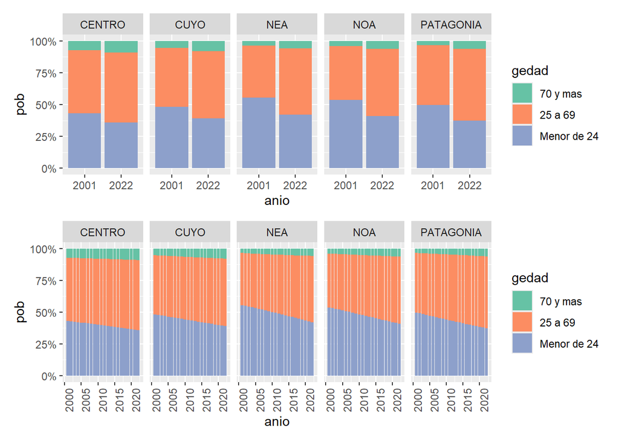

```r
patchwork::wrap_plots(grafico1, grafico2, ncol = 1)
```

Se observan diferencias considerables entre las regiones de NOA y NEA en terminos de que mas del 50% es menor de 24 años. Para todas las regiones se denota un decrecimiento relativo de este grupo de edad, y un crecimiento en las edades centrales 25 a 69 años. Mientras la mayor proporcion de mayores se encuentra en la region Centro, seguida por Cuyo.

```r
#data_pob_reg

data_pob |>
  group_by_at(var_agg_prov) |>
  summarise( pob = round(sum(pob_est, na.rm = TRUE),0)) |>
  ungroup() |>
  left_join(regiones, by=c("geocodigo_prov" = "code_prov")) |>
  select(region, anio, gedad, sexo, pob) |>
  group_by_at(var_agg_reg) |>
  summarise(pob = sum(pob, na.rm = TRUE)) |>
  ungroup()-> data_pob_reg

head(data_pob_reg)
```

```
## # A tibble: 6 × 5
##    anio region gedad       sexo      pob
##   <int> <chr>  <chr>       <chr>   <dbl>
## 1  2001 CENTRO 25 a 69     Mujer 6181913
## 2  2001 CENTRO 25 a 69     Varón 5713019
## 3  2001 CENTRO 70 y mas    Mujer 1062949
## 4  2001 CENTRO 70 y mas    Varón  665538
## 5  2001 CENTRO Menor de 24 Mujer 5096367
## 6  2001 CENTRO Menor de 24 Varón 5212217
```

### 1.1.1 Defunciones por regiones

Se calcula la razon del trienio, de defunciones por grupo de causas, segun edad y sexo, por regiones.

```r
var_agg_def_prov <- c("anio", "Años", "gedad", "sexo", "geocodigo_provincia", "grupo_oms")

data |>
  filter(!is.na(gedad), !is.na(sexo), !is.na(grupo_oms), !is.na(geocodigo_provincia)) |>
  group_by_at(var_agg_def_prov) |>
  summarise(
    casos = sum(casos, na.rm=TRUE)
  ) |>
  ungroup() -> data_def_prov
```

```r
var_agg_def_reg <- c("anio", "Años", "gedad","sexo", "region", "grupo_oms")
# data_def_reg
data_def_prov |>
  left_join(regiones, by=c("geocodigo_provincia" = "code_prov")) |>
  group_by_at(var_agg_def_reg) |>
  summarise(
    casos = sum(casos, na.rm = TRUE)
  ) |>
  ungroup()-> data_def_reg

head(data_def_reg)
```

```
## # A tibble: 6 × 7
##    anio Años      gedad       sexo  region grupo_oms                       casos
##   <dbl> <chr>     <fct>       <chr> <chr>  <chr>                           <int>
## 1  2003 2001-2004 Menor de 24 Mujer CENTRO Condiciones transmisibles, mat…  7094
## 2  2003 2001-2004 Menor de 24 Mujer CENTRO Enfermedades mal definidas        636
## 3  2003 2001-2004 Menor de 24 Mujer CENTRO Enfermedades no transmisibles    7162
## 4  2003 2001-2004 Menor de 24 Mujer CENTRO Lesiones                         2853
## 5  2003 2001-2004 Menor de 24 Mujer CUYO   Condiciones transmisibles, mat…   887
## 6  2003 2001-2004 Menor de 24 Mujer CUYO   Enfermedades mal definidas         25
```

```r
data_def_reg |>
  left_join(data_pob_reg, by=c("anio", "gedad","sexo", "region")) |>
  mutate(
    rm = round(casos/pob, 7), # Razon de mortalidad
    rmxm = round(rm * 100000,0) # Razon x 100.000
  )-> data_mort_reg

head(data_mort_reg)
```

```
## # A tibble: 6 × 10
##    anio Años      gedad       sexo  region grupo_oms  casos    pob      rm  rmxm
##   <dbl> <chr>     <chr>       <chr> <chr>  <chr>      <int>  <dbl>   <dbl> <dbl>
## 1  2003 2001-2004 Menor de 24 Mujer CENTRO Condicion…  7094 5.15e6 1.38e-3   138
## 2  2003 2001-2004 Menor de 24 Mujer CENTRO Enfermeda…   636 5.15e6 1.24e-4    12
## 3  2003 2001-2004 Menor de 24 Mujer CENTRO Enfermeda…  7162 5.15e6 1.39e-3   139
## 4  2003 2001-2004 Menor de 24 Mujer CENTRO Lesiones    2853 5.15e6 5.54e-4    55
## 5  2003 2001-2004 Menor de 24 Mujer CUYO   Condicion…   887 6.09e5 1.46e-3   146
## 6  2003 2001-2004 Menor de 24 Mujer CUYO   Enfermeda…    25 6.09e5 4.1 e-5     4
```

### 1.1.2 Grafico de la distribucion

Distribucion de defunciones (la frecuencia relativa) segun causas por region, refleja las diferencias en la estructura por edades.

```r
data_mort_reg |>
  filter(sexo == "Varón") |>
    mutate(
      gedad = factor(gedad, levels = c("Menor de 24", "25 a 69", "70 y mas"), ordered = TRUE)
    ) |>
  ggplot(aes(Años, casos, fill=grupo_oms, group = region))+
  geom_col(position = "fill")+
  # scale_x_continuous(breaks = data_mort_reg$anio, labels = data_mort_reg$Años)+
  facet_grid(gedad~region)+
  labs(
    title = "Distribucion de las defunciones segun grupos de causas",
    subtitle = "Varones"
  )+
  theme(
    axis.text.x = element_blank(),
    axis.line.x = element_blank(),
    axis.title.x = element_blank(),
    legend.position = "None",
    strip.text = element_text(size = 7, margin = margin()),
    strip.background.x = element_rect(size = 5),
    strip.text.y = element_text(angle = 0)
    )+
  guides(fill=guide_legend(ncol=2))-> grafico3

data_mort_reg |>
  filter(sexo == "Mujer") |>
    mutate(
      gedad = factor(gedad, levels = c("Menor de 24", "25 a 69", "70 y mas"), ordered = TRUE)
    ) |>
  ggplot(aes(Años, casos, fill=grupo_oms, group = region))+
  geom_col(position = "fill")+
  # scale_x_continuous(breaks = data_mort_reg$anio, labels = data_mort_reg$Años)+
  facet_grid(gedad~region)+
  labs(
    subtitle = "Mujeres"
  )+
  theme(
    axis.text.x = element_text(angle = 90, hjust = 1),
    legend.position = "bottom",
    strip.text = element_text(size = 7, margin = margin()),
    strip.background.x = element_rect(size = 5),
    strip.text.y = element_text(angle = 0)
    )+
  guides(fill=guide_legend(ncol=2))-> grafico4
```

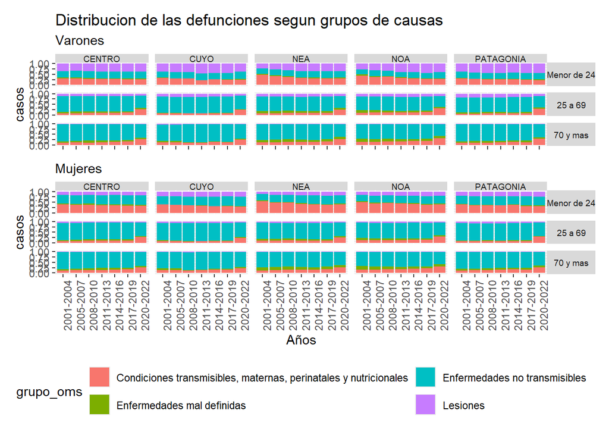

```r
patchwork::wrap_plots(grafico3, grafico4, ncol = 1)
```

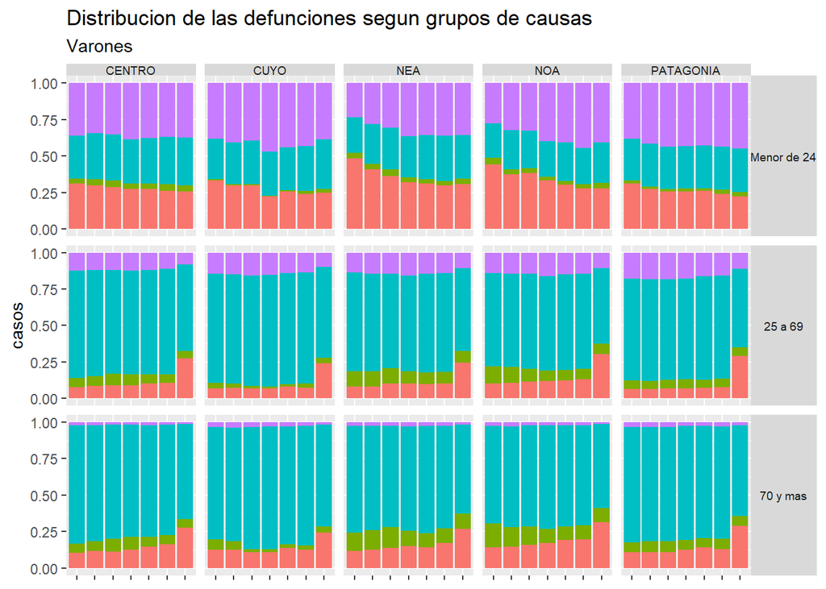

```r
grafico3
```

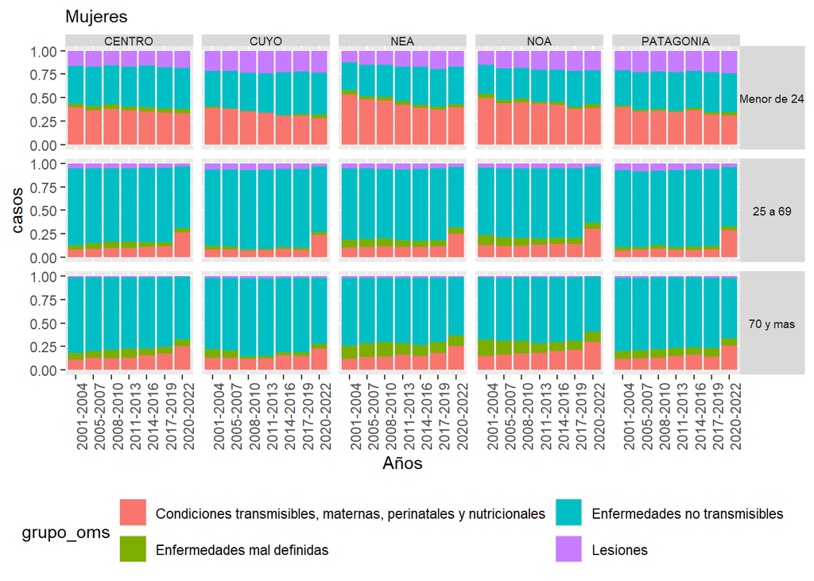

```r
grafico4
```

Se muestran las diferencias por edades en tanto las defunciones por causas externas o Lesiones, decrecen con la edad. Que en el grupo jovenes o 0 a 24, se concentran en varones, mientras en mujeres son las Enfermedades infecto contagiosas y maternas. En las edad centrales estas diferencias se diluyen con una leve mayor frecuencia de causas externas en varones. Mientras que en edades adultas hay mas mal definidas en mujeres, con diferencias significativas entre regiones.

Se puede observar la evolucion de la tasa (razon por cien mil en el trienio) en una tabla para cada region.

#### 1.1.2.1 Evolucion de la Mortalidad

Se puede comparar a escala regional la Razon de mortalidad de trienio segun edad y sexo, por grupo de causas

**Ver tabla**

```r
kableExtra::kbl(

data_mort_reg |>
  filter(anio != 2003) |>
  select(region, gedad, grupo_oms, Años, sexo, rmxm) |>
  mutate(
    gedad = factor(gedad, levels = c("Menor de 24", "25 a 69", "70 y mas"), ordered = TRUE)
  ) |>
  arrange(region, gedad, grupo_oms, sexo) |>
  pivot_wider(
    names_from = Años,
    values_from = rmxm
  ),
caption = "Razon de mortalidad (x100.000) segun grupo de edad, gran grupo de causas y sexo, en trienios, Argentina"
) |>
  kableExtra::kable_styling() |>
  kableExtra::column_spec(1:3, bold = T) |>
  kableExtra::collapse_rows(columns = 1:3, valign = "top") |>
  kableExtra::footnote(general = "Elaboracion propia con datos de DEIS y OMS")
```

Razon de mortalidad (x100.000) segun grupo de edad, gran grupo de causas y sexo, en trienios, Argentina

| region | gedad | grupo_oms | sexo | 2005-2007 | 2008-2010 | 2011-2013 | 2014-2016 | 2017-2019 | 2020-2022 |
| --- | --- | --- | --- | --- | --- | --- | --- | --- | --- |
| CENTRO | Menor de 24 | Condiciones transmisibles, maternas, perinatales y nutricionales | Mujer | 86 | 89 | 81 | 72 | 61 | 47 |
|  |  |  | Varón | 111 | 109 | 102 | 93 | 75 | 59 |
|  |  | Enfermedades mal definidas | Mujer | 10 | 11 | 9 | 9 | 8 | 6 |
|  |  |  | Varón | 15 | 16 | 14 | 13 | 13 | 9 |
|  |  | Enfermedades no transmisibles | Mujer | 99 | 96 | 94 | 88 | 77 | 62 |
|  |  |  | Varón | 118 | 120 | 114 | 106 | 94 | 75 |
|  |  | Lesiones | Mujer | 39 | 37 | 38 | 32 | 31 | 25 |
|  |  |  | Varón | 127 | 133 | 143 | 129 | 106 | 85 |
|  | 25 a 69 | Condiciones transmisibles, maternas, perinatales y nutricionales | Mujer | 103 | 107 | 107 | 118 | 116 | 313 |
|  |  |  | Varón | 182 | 185 | 180 | 194 | 189 | 561 |
|  |  | Enfermedades mal definidas | Mujer | 58 | 72 | 70 | 51 | 48 | 51 |
|  |  |  | Varón | 145 | 158 | 145 | 115 | 104 | 105 |
|  |  | Enfermedades no transmisibles | Mujer | 872 | 838 | 834 | 829 | 790 | 775 |
|  |  |  | Varón | 1553 | 1441 | 1390 | 1348 | 1261 | 1217 |
|  |  | Lesiones | Mujer | 60 | 55 | 55 | 52 | 47 | 39 |
|  |  |  | Varón | 252 | 244 | 240 | 222 | 197 | 172 |
|  | 70 y mas | Condiciones transmisibles, maternas, perinatales y nutricionales | Mujer | 2518 | 2308 | 2441 | 2915 | 3093 | 4898 |
|  |  |  | Varón | 3012 | 2795 | 2958 | 3473 | 3662 | 6820 |
|  |  | Enfermedades mal definidas | Mujer | 1457 | 1748 | 1817 | 1313 | 1170 | 1278 |
|  |  |  | Varón | 1806 | 2132 | 2171 | 1532 | 1373 | 1435 |
|  |  | Enfermedades no transmisibles | Mujer | 15271 | 14340 | 14055 | 13926 | 12967 | 12795 |
|  |  |  | Varón | 20809 | 19138 | 18472 | 18139 | 16802 | 15916 |
|  |  | Lesiones | Mujer | 329 | 261 | 274 | 298 | 255 | 210 |
|  |  |  | Varón | 575 | 480 | 470 | 485 | 406 | 367 |
| CUYO | Menor de 24 | Condiciones transmisibles, maternas, perinatales y nutricionales | Mujer | 98 | 84 | 70 | 63 | 52 | 40 |
|  |  |  | Varón | 117 | 113 | 78 | 86 | 69 | 54 |
|  |  | Enfermedades mal definidas | Mujer | 1 | 1 | 1 | 2 | 4 | 5 |
|  |  |  | Varón | 3 | 3 | 2 | 2 | 6 | 6 |
|  |  | Enfermedades no transmisibles | Mujer | 103 | 96 | 86 | 91 | 75 | 63 |
|  |  |  | Varón | 112 | 114 | 106 | 100 | 88 | 74 |

[output cut: 90 more lines]

Note:  
Elaboracion propia con datos de DEIS y OMS

Para una mejor presentacion de los datos, se prsentan los resultados para cada region por separado.

##### 1.1.2.1.1 NOA

Razon de mortalidad (x100.000) segun grupo de edad, gran grupo de causas y sexo, en trienios, Argentina

| region | gedad | grupo_oms | sexo | 2005-2007 | 2008-2010 | 2011-2013 | 2014-2016 | 2017-2019 | 2020-2022 |
| --- | --- | --- | --- | --- | --- | --- | --- | --- | --- |
| NOA | Menor de 24 | Condiciones transmisibles, maternas, perinatales y nutricionales | Mujer | 124 | 129 | 117 | 107 | 85 | 73 |
|  |  |  | Varón | 148 | 158 | 144 | 124 | 104 | 82 |
|  |  | Enfermedades mal definidas | Mujer | 11 | 11 | 6 | 8 | 7 | 7 |
|  |  |  | Varón | 14 | 14 | 12 | 10 | 10 | 10 |
|  |  | Enfermedades no transmisibles | Mujer | 94 | 94 | 90 | 87 | 84 | 67 |
|  |  |  | Varón | 106 | 107 | 104 | 108 | 93 | 81 |
|  |  | Lesiones | Mujer | 54 | 52 | 54 | 50 | 49 | 39 |
|  |  |  | Varón | 128 | 135 | 173 | 166 | 167 | 120 |
|  | 25 a 69 | Condiciones transmisibles, maternas, perinatales y nutricionales | Mujer | 130 | 134 | 142 | 152 | 145 | 367 |
|  |  |  | Varón | 202 | 218 | 221 | 230 | 230 | 623 |
|  |  | Enfermedades mal definidas | Mujer | 99 | 85 | 69 | 66 | 63 | 75 |
|  |  |  | Varón | 204 | 171 | 135 | 129 | 129 | 148 |
|  |  | Enfermedades no transmisibles | Mujer | 773 | 782 | 774 | 773 | 754 | 715 |
|  |  |  | Varón | 1188 | 1240 | 1214 | 1215 | 1150 | 1055 |
|  |  | Lesiones | Mujer | 59 | 60 | 59 | 55 | 56 | 46 |
|  |  |  | Varón | 268 | 274 | 300 | 277 | 259 | 220 |
|  | 70 y mas | Condiciones transmisibles, maternas, perinatales y nutricionales | Mujer | 2783 | 2997 | 2988 | 3318 | 3428 | 5417 |
|  |  |  | Varón | 3383 | 3589 | 3688 | 4162 | 4133 | 7574 |
|  |  | Enfermedades mal definidas | Mujer | 2592 | 2299 | 1705 | 1583 | 1636 | 1972 |
|  |  |  | Varón | 3215 | 2900 | 2086 | 1976 | 2052 | 2406 |
|  |  | Enfermedades no transmisibles | Mujer | 11611 | 11548 | 11413 | 11403 | 10868 | 10644 |
|  |  |  | Varón | 16147 | 15807 | 15436 | 15021 | 14332 | 13873 |
|  |  | Lesiones | Mujer | 347 | 250 | 213 | 240 | 202 | 188 |
|  |  |  | Varón | 692 | 533 | 482 | 469 | 453 | 366 |

Note:  
Elaboracion propia con datos de DEIS y OMS

##### 1.1.2.1.2 NEA

Razon de mortalidad (x100.000) segun grupo de edad, gran grupo de causas y sexo, en trienios, Argentina

| region | gedad | grupo_oms | sexo | 2005-2007 | 2008-2010 | 2011-2013 | 2014-2016 | 2017-2019 | 2020-2022 |
| --- | --- | --- | --- | --- | --- | --- | --- | --- | --- |
| NEA | Menor de 24 | Condiciones transmisibles, maternas, perinatales y nutricionales | Mujer | 160 | 154 | 127 | 109 | 94 | 91 |
|  |  |  | Varón | 199 | 172 | 145 | 143 | 124 | 109 |
|  |  | Enfermedades mal definidas | Mujer | 10 | 12 | 12 | 9 | 8 | 8 |
|  |  |  | Varón | 19 | 20 | 15 | 13 | 11 | 12 |
|  |  | Enfermedades no transmisibles | Mujer | 110 | 109 | 109 | 112 | 102 | 91 |
|  |  |  | Varón | 133 | 135 | 130 | 138 | 128 | 106 |
|  |  | Lesiones | Mujer | 51 | 50 | 50 | 47 | 49 | 38 |
|  |  |  | Varón | 137 | 145 | 165 | 164 | 148 | 126 |
|  | 25 a 69 | Condiciones transmisibles, maternas, perinatales y nutricionales | Mujer | 132 | 139 | 131 | 128 | 131 | 334 |
|  |  |  | Varón | 177 | 215 | 218 | 209 | 207 | 572 |
|  |  | Enfermedades mal definidas | Mujer | 94 | 102 | 78 | 75 | 74 | 83 |
|  |  |  | Varón | 219 | 226 | 177 | 171 | 163 | 184 |
|  |  | Enfermedades no transmisibles | Mujer | 881 | 883 | 861 | 885 | 872 | 846 |
|  |  |  | Varón | 1418 | 1383 | 1402 | 1443 | 1387 | 1323 |
|  |  | Lesiones | Mujer | 63 | 71 | 75 | 67 | 64 | 57 |
|  |  |  | Varón | 303 | 311 | 331 | 309 | 288 | 246 |
|  | 70 y mas | Condiciones transmisibles, maternas, perinatales y nutricionales | Mujer | 2439 | 2493 | 2683 | 2612 | 3032 | 4690 |
|  |  |  | Varón | 3029 | 3321 | 3468 | 3292 | 3782 | 6741 |
|  |  | Enfermedades mal definidas | Mujer | 2724 | 2557 | 2092 | 1957 | 1943 | 2224 |
|  |  |  | Varón | 3325 | 3321 | 2412 | 2341 | 2247 | 2683 |
|  |  | Enfermedades no transmisibles | Mujer | 12491 | 11741 | 11542 | 12361 | 11427 | 11479 |
|  |  |  | Varón | 17343 | 16555 | 16478 | 17231 | 15498 | 15436 |
|  |  | Lesiones | Mujer | 346 | 343 | 370 | 333 | 407 | 296 |
|  |  |  | Varón | 663 | 632 | 676 | 642 | 614 | 486 |

Note:  
Elaboracion propia con datos de DEIS y OMS

##### 1.1.2.1.3 CENTRO

Razon de mortalidad (x100.000) segun grupo de edad, gran grupo de causas y sexo, en trienios, Argentina

| region | gedad | grupo_oms | sexo | 2005-2007 | 2008-2010 | 2011-2013 | 2014-2016 | 2017-2019 | 2020-2022 |
| --- | --- | --- | --- | --- | --- | --- | --- | --- | --- |
| CENTRO | Menor de 24 | Condiciones transmisibles, maternas, perinatales y nutricionales | Mujer | 86 | 89 | 81 | 72 | 61 | 47 |
|  |  |  | Varón | 111 | 109 | 102 | 93 | 75 | 59 |
|  |  | Enfermedades mal definidas | Mujer | 10 | 11 | 9 | 9 | 8 | 6 |
|  |  |  | Varón | 15 | 16 | 14 | 13 | 13 | 9 |
|  |  | Enfermedades no transmisibles | Mujer | 99 | 96 | 94 | 88 | 77 | 62 |
|  |  |  | Varón | 118 | 120 | 114 | 106 | 94 | 75 |
|  |  | Lesiones | Mujer | 39 | 37 | 38 | 32 | 31 | 25 |
|  |  |  | Varón | 127 | 133 | 143 | 129 | 106 | 85 |
|  | 25 a 69 | Condiciones transmisibles, maternas, perinatales y nutricionales | Mujer | 103 | 107 | 107 | 118 | 116 | 313 |
|  |  |  | Varón | 182 | 185 | 180 | 194 | 189 | 561 |
|  |  | Enfermedades mal definidas | Mujer | 58 | 72 | 70 | 51 | 48 | 51 |
|  |  |  | Varón | 145 | 158 | 145 | 115 | 104 | 105 |
|  |  | Enfermedades no transmisibles | Mujer | 872 | 838 | 834 | 829 | 790 | 775 |
|  |  |  | Varón | 1553 | 1441 | 1390 | 1348 | 1261 | 1217 |
|  |  | Lesiones | Mujer | 60 | 55 | 55 | 52 | 47 | 39 |
|  |  |  | Varón | 252 | 244 | 240 | 222 | 197 | 172 |
|  | 70 y mas | Condiciones transmisibles, maternas, perinatales y nutricionales | Mujer | 2518 | 2308 | 2441 | 2915 | 3093 | 4898 |
|  |  |  | Varón | 3012 | 2795 | 2958 | 3473 | 3662 | 6820 |
|  |  | Enfermedades mal definidas | Mujer | 1457 | 1748 | 1817 | 1313 | 1170 | 1278 |
|  |  |  | Varón | 1806 | 2132 | 2171 | 1532 | 1373 | 1435 |
|  |  | Enfermedades no transmisibles | Mujer | 15271 | 14340 | 14055 | 13926 | 12967 | 12795 |
|  |  |  | Varón | 20809 | 19138 | 18472 | 18139 | 16802 | 15916 |
|  |  | Lesiones | Mujer | 329 | 261 | 274 | 298 | 255 | 210 |
|  |  |  | Varón | 575 | 480 | 470 | 485 | 406 | 367 |

Note:  
Elaboracion propia con datos de DEIS y OMS

##### 1.1.2.1.4 CUYO

Razon de mortalidad (x100.000) segun grupo de edad, gran grupo de causas y sexo, en trienios, Argentina

| region | gedad | grupo_oms | sexo | 2005-2007 | 2008-2010 | 2011-2013 | 2014-2016 | 2017-2019 | 2020-2022 |
| --- | --- | --- | --- | --- | --- | --- | --- | --- | --- |
| CUYO | Menor de 24 | Condiciones transmisibles, maternas, perinatales y nutricionales | Mujer | 98 | 84 | 70 | 63 | 52 | 40 |
|  |  |  | Varón | 117 | 113 | 78 | 86 | 69 | 54 |
|  |  | Enfermedades mal definidas | Mujer | 1 | 1 | 1 | 2 | 4 | 5 |
|  |  |  | Varón | 3 | 3 | 2 | 2 | 6 | 6 |
|  |  | Enfermedades no transmisibles | Mujer | 103 | 96 | 86 | 91 | 75 | 63 |
|  |  |  | Varón | 112 | 114 | 106 | 100 | 88 | 74 |
|  |  | Lesiones | Mujer | 56 | 55 | 49 | 46 | 37 | 33 |
|  |  |  | Varón | 159 | 149 | 165 | 147 | 124 | 85 |
|  | 25 a 69 | Condiciones transmisibles, maternas, perinatales y nutricionales | Mujer | 91 | 74 | 80 | 92 | 76 | 265 |
|  |  |  | Varón | 139 | 123 | 119 | 135 | 115 | 443 |
|  |  | Enfermedades mal definidas | Mujer | 29 | 17 | 14 | 19 | 25 | 34 |
|  |  |  | Varón | 49 | 28 | 24 | 29 | 47 | 70 |
|  |  | Enfermedades no transmisibles | Mujer | 852 | 879 | 856 | 845 | 790 | 772 |
|  |  |  | Varón | 1389 | 1351 | 1326 | 1259 | 1210 | 1147 |
|  |  | Lesiones | Mujer | 70 | 75 | 70 | 61 | 59 | 42 |
|  |  |  | Varón | 277 | 283 | 267 | 231 | 216 | 186 |
|  | 70 y mas | Condiciones transmisibles, maternas, perinatales y nutricionales | Mujer | 2538 | 2112 | 2191 | 2769 | 2463 | 4145 |
|  |  |  | Varón | 3000 | 2475 | 2421 | 2995 | 2657 | 5729 |
|  |  | Enfermedades mal definidas | Mujer | 1411 | 448 | 394 | 484 | 642 | 901 |
|  |  |  | Varón | 1501 | 515 | 447 | 540 | 706 | 1016 |
|  |  | Enfermedades no transmisibles | Mujer | 14547 | 14929 | 14468 | 13686 | 13148 | 12832 |
|  |  |  | Varón | 19016 | 19403 | 18734 | 17807 | 17588 | 16419 |
|  |  | Lesiones | Mujer | 476 | 490 | 441 | 421 | 401 | 381 |
|  |  |  | Varón | 906 | 799 | 702 | 622 | 570 | 465 |

Note:  
Elaboracion propia con datos de DEIS y OMS

##### 1.1.2.1.5 PATAGONIA

Razon de mortalidad (x100.000) segun grupo de edad, gran grupo de causas y sexo, en trienios, Argentina

| region | gedad | grupo_oms | sexo | 2005-2007 | 2008-2010 | 2011-2013 | 2014-2016 | 2017-2019 | 2020-2022 |
| --- | --- | --- | --- | --- | --- | --- | --- | --- | --- |
| PATAGONIA | Menor de 24 | Condiciones transmisibles, maternas, perinatales y nutricionales | Mujer | 76 | 77 | 68 | 68 | 50 | 41 |
|  |  |  | Varón | 98 | 93 | 90 | 85 | 67 | 53 |
|  |  | Enfermedades mal definidas | Mujer | 4 | 4 | 3 | 5 | 4 | 5 |
|  |  |  | Varón | 6 | 6 | 7 | 6 | 9 | 7 |
|  |  | Enfermedades no transmisibles | Mujer | 86 | 84 | 81 | 74 | 66 | 54 |
|  |  |  | Varón | 105 | 106 | 102 | 96 | 82 | 71 |
|  |  | Lesiones | Mujer | 48 | 48 | 45 | 39 | 35 | 31 |
|  |  |  | Varón | 148 | 159 | 153 | 139 | 122 | 107 |
|  | 25 a 69 | Condiciones transmisibles, maternas, perinatales y nutricionales | Mujer | 71 | 77 | 64 | 67 | 71 | 292 |
|  |  |  | Varón | 113 | 119 | 117 | 116 | 116 | 553 |
|  |  | Enfermedades mal definidas | Mujer | 27 | 36 | 28 | 31 | 33 | 39 |
|  |  |  | Varón | 101 | 101 | 100 | 84 | 90 | 111 |
|  |  | Enfermedades no transmisibles | Mujer | 689 | 673 | 668 | 683 | 661 | 639 |
|  |  |  | Varón | 1238 | 1163 | 1146 | 1126 | 1063 | 1024 |
|  |  | Lesiones | Mujer | 72 | 68 | 62 | 57 | 52 | 40 |
|  |  |  | Varón | 322 | 312 | 295 | 259 | 235 | 212 |
|  | 70 y mas | Condiciones transmisibles, maternas, perinatales y nutricionales | Mujer | 2065 | 2069 | 2307 | 2532 | 2177 | 4442 |
|  |  |  | Varón | 2471 | 2364 | 2656 | 2958 | 2572 | 6776 |
|  |  | Enfermedades mal definidas | Mujer | 1325 | 1380 | 1256 | 1184 | 1299 | 1391 |
|  |  |  | Varón | 1638 | 1639 | 1465 | 1319 | 1460 | 1587 |
|  |  | Enfermedades no transmisibles | Mujer | 12607 | 11730 | 11432 | 11297 | 11157 | 11027 |
|  |  |  | Varón | 17651 | 17016 | 16585 | 16278 | 15588 | 14568 |
|  |  | Lesiones | Mujer | 353 | 289 | 238 | 278 | 322 | 334 |
|  |  |  | Varón | 778 | 715 | 587 | 526 | 573 | 482 |

Note:  
Elaboracion propia con datos de DEIS y OMS

```r
data_mort_reg
```

```
## # A tibble: 840 × 10
##     anio Años      gedad       sexo  region grupo_oms casos    pob      rm  rmxm
##    <dbl> <chr>     <chr>       <chr> <chr>  <chr>     <int>  <dbl>   <dbl> <dbl>
##  1  2003 2001-2004 Menor de 24 Mujer CENTRO Condicio…  7094 5.15e6 1.38e-3   138
##  2  2003 2001-2004 Menor de 24 Mujer CENTRO Enfermed…   636 5.15e6 1.24e-4    12
##  3  2003 2001-2004 Menor de 24 Mujer CENTRO Enfermed…  7162 5.15e6 1.39e-3   139
##  4  2003 2001-2004 Menor de 24 Mujer CENTRO Lesiones   2853 5.15e6 5.54e-4    55
##  5  2003 2001-2004 Menor de 24 Mujer CUYO   Condicio…   887 6.09e5 1.46e-3   146
##  6  2003 2001-2004 Menor de 24 Mujer CUYO   Enfermed…    25 6.09e5 4.1 e-5     4
##  7  2003 2001-2004 Menor de 24 Mujer CUYO   Enfermed…   851 6.09e5 1.40e-3   140
##  8  2003 2001-2004 Menor de 24 Mujer CUYO   Lesiones    477 6.09e5 7.83e-4    78
##  9  2003 2001-2004 Menor de 24 Mujer NEA    Condicio…  2764 9.19e5 3.01e-3   301
## 10  2003 2001-2004 Menor de 24 Mujer NEA    Enfermed…   223 9.19e5 2.43e-4    24
## # ℹ 830 more rows
```

### 1.1.3 Grafico de la Evolucion

Aunque graficar todo junto puede resultar atractivo, ciertas causas estan relacioneadas claramente con el sexo y la edad. Problemas de datos al inicio y fin de la serie Inicio es un cuatrienio y el final es Pandemia

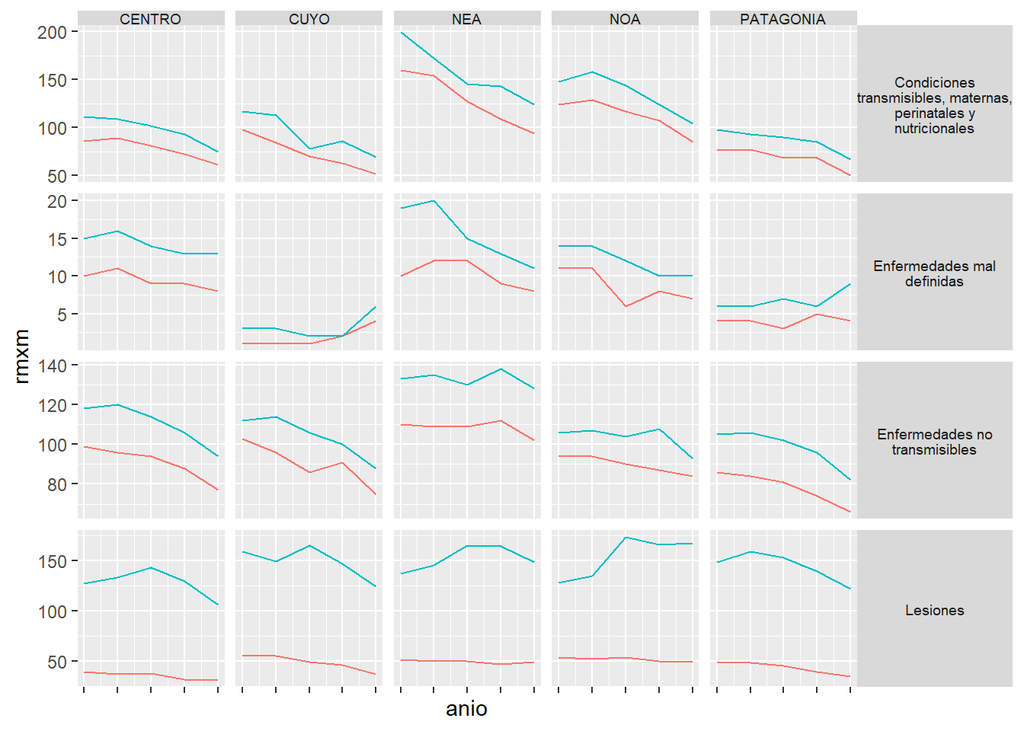

```r
data_mort_reg |>
  filter(gedad == "Menor de 24", !anio %in% c(2003, 2021)) |>
  ggplot(aes(anio, rmxm, colour = sexo))+
  geom_line()+
  scale_x_continuous(breaks = anios, labels = label_anios)+
  facet_grid(grupo_oms~region, scales="free_y", labeller = label_wrap_gen(multi_line = TRUE) )+
  theme(
    legend.position = "None",
    axis.text.x = element_blank(),
    axis.line.x = element_blank(),
    strip.text = element_text(size = 7, margin = margin()),
    strip.background.x = element_rect(size = 5),
    strip.text.y = element_text(angle = 0)
  )-> grafico5
grafico5
```

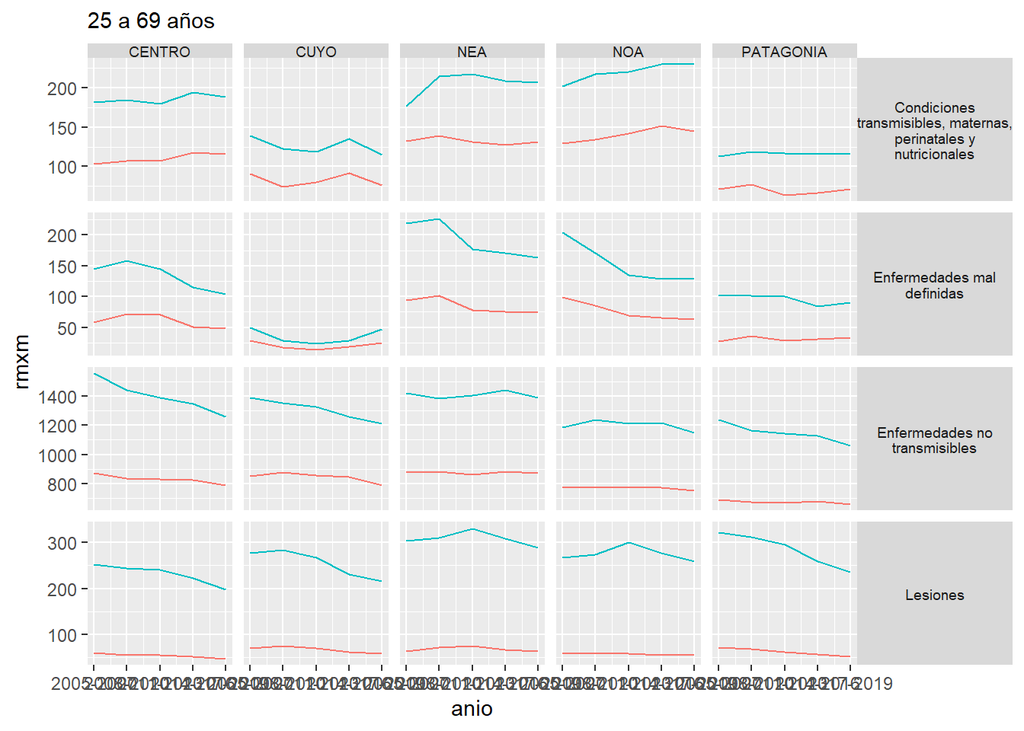

```r
data_mort_reg |>
  filter(gedad == "25 a 69", !anio %in% c(2003, 2021) ) |>
  ggplot(aes(anio, rmxm, colour = sexo))+
  geom_line()+
  scale_x_continuous(breaks = anios, labels = label_anios)+
  facet_grid(grupo_oms~region, scales="free", labeller = label_wrap_gen(multi_line = TRUE))+
  labs(subtitle = "25 a 69 años")+
  theme(
    legend.position = "None",
    strip.text = element_text(size = 7, margin = margin()),
    strip.background.x = element_rect(size = 5),
    strip.text.y = element_text(angle = 0)
  )-> grafico6
grafico6
```

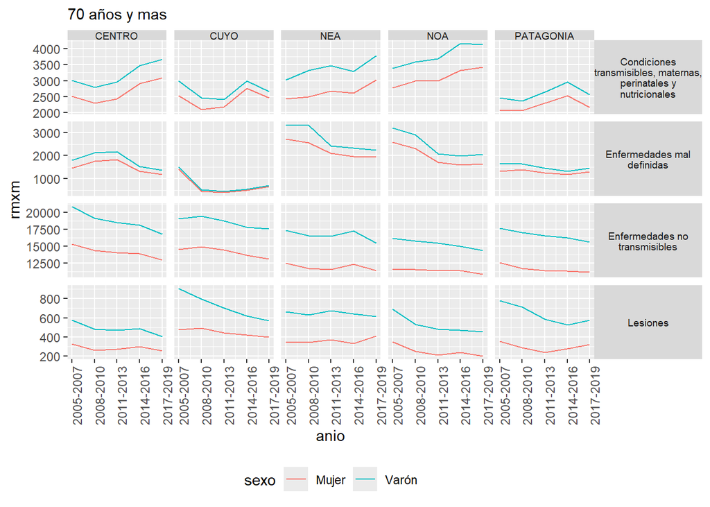

```r
data_mort_reg |>
  filter(gedad == "70 y mas", !anio %in% c(2003, 2021)) |>
  ggplot(aes(anio, rmxm, colour = sexo))+
  geom_line()+
   scale_x_continuous(breaks = anios, labels = label_anios)+
  facet_grid(grupo_oms~region, scales="free_y", labeller = label_wrap_gen(multi_line = TRUE))+
  labs(subtitle = "70 años y mas")+
  theme(
    legend.position = "bottom",
    strip.text = element_text(size = 7, margin = margin()),
    strip.background.x = element_rect(size = 5),
    strip.text.y = element_text(angle = 0),
    axis.text.x = element_text(angle = 90)
  )-> grafico7
grafico7
```

### Evolucion por causas de Jovenes

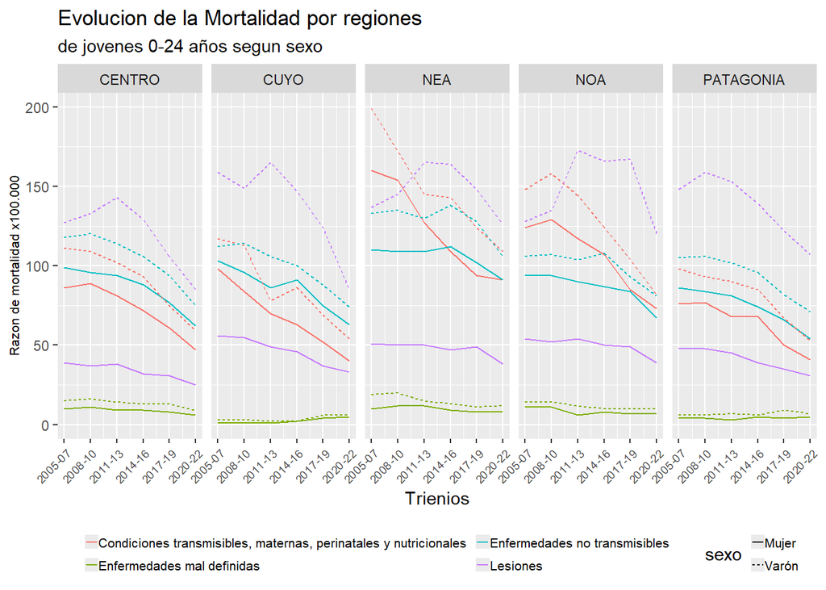

```r
anios2 <- c(2006, 2009, 2012, 2015, 2018, 2021)
label_anios2 <- c("2005-2007", "2008-2010", "2011-2013", "2014-2016", "2017-2019", "2020-2022")

data_mort_reg |>
  filter(anio != 2003, gedad == "Menor de 24") |>
  ggplot(aes(anio, rmxm, colour = grupo_oms))+
  geom_line(aes(linetype = sexo))+
  facet_grid(~region, scales="free_y")+
  scale_x_continuous(breaks = anios2, labels = label_anios3)+
  theme(
    legend.position = "bottom",
    legend.text = element_text(size=8,margin = margin()),
    legend.key.size = unit(.3, "cm"),
    axis.text.x = element_text(angle = 45, size = 7, hjust = 1),
    axis.title.y = element_text(size=8)
  )+
  labs(
    title = "Evolucion de la Mortalidad por regiones",
    subtitle = "de jovenes 0-24 años segun sexo",
    y = "Razon de mortalidad x100.000",
    x= "Trienios",
    color=""
  )+
  guides(colour=guide_legend(nrow=2),
         linetype = guide_legend(nrwo = 2, ncol = 1),
         )
```

```r
# ggsave("salida_graf/grfico_jovenes_regiones.png")
```

Al observar la evolucion de la mortalidad en jovenes, o edades iniciales, 0 a 24, se observa que:  
- Se destaca el claro descenso en la mortalidad por condiciones transmisibles, maternas, perinatales y nutricionales, sobre todo en donde eran inicialmente mas altas, NOA y NEA. Aunque se destacan diferencias considerables en el nivel entre regiones. La baja en el grupo de causas, explica que se redujeran las diferencias interregionales ya que: en el presente la principal causa de mortalidad en varones sean las causas Externas o Lesiones, cuando al inicio de la serie en NOA y NEA lo eran claramente las debidas a Enf. contagiosas; y que en Mujeres la principal causa sean las Enf. No trasnmisible, ya que la la serie muestra que aunque sean casi iguales en NOA y NEA la razon por estas causas (No transmisibles y Transmisibles, y maternas), de mantener el ritmo de descenso el patron entre las causas, tenderia a converger.El hecho es que la mortalidad por enefermedades no tranmisibles, no bajó tanto como las primeras. Ya que salvo las diferencias en la razon por Enf. Mal definidas, y en Lesiones en mujeres, estas se mantuvieron casi constantes.

**Click para ver la tabla**

```r
data_mort_reg |>
  filter(anio %in% c(2006, 2018, 2021), gedad == "Menor de 24") |>
  distinct(anio,sexo, region, grupo_oms, rmxm) |>
  arrange(grupo_oms, region, sexo) |>
  mutate(
    var = lag(rmxm, n = 1),
    TC = scales::percent((rmxm - var) / var, accuracy = .1)
  )  |>
  select(-var) |>
  pivot_wider(
    names_from = anio,
    values_from = c(rmxm, TC)
  ) |>
  select(-TC_2006) |>
  arrange(sexo, grupo_oms, region) |>
  relocate(region, .after = grupo_oms) |>
  mutate(
    TC_2018 = kableExtra::cell_spec(TC_2018, "html", color = ifelse(TC_2018 > 0 , "orange4", "green4")),
    TC_2021 = kableExtra::cell_spec(TC_2021, "html", color = ifelse(TC_2021 > 0, "orange4", "green4"))
  ) |>
  kableExtra::kbl(caption = "Variacion Razon de Mortalidad segun causa y region, 0 a 24 años",
                  format = "html", escape = F) |>
  # kableExtra::kable_paper("striped", full_width = F)
  kableExtra::kable_styling() |>
  kableExtra::column_spec(1:3, bold = T) |>
  kableExtra::collapse_rows(columns = 1:3, valign = "top") |>
  kableExtra::footnote(general = "Elaboracion propia con datos de DEIS y OMS")
```

Variacion Razon de Mortalidad segun causa y region, 0 a 24 años

| sexo | grupo_oms | region | rmxm_2006 | rmxm_2018 | rmxm_2021 | TC_2018 | TC_2021 |
| --- | --- | --- | --- | --- | --- | --- | --- |
| Mujer | Condiciones transmisibles, maternas, perinatales y nutricionales | CENTRO | 86 | 61 | 47 | -29.1% | -23.0% |
|  |  | CUYO | 98 | 52 | 40 | -46.9% | -23.1% |
|  |  | NEA | 160 | 94 | 91 | -41.2% | -3.2% |
|  |  | NOA | 124 | 85 | 73 | -31.5% | -14.1% |
|  |  | PATAGONIA | 76 | 50 | 41 | -34.2% | -18.0% |
|  | Enfermedades mal definidas | CENTRO | 10 | 8 | 6 | -20.0% | -25.0% |
|  |  | CUYO | 1 | 4 | 5 | 300.0% | 25.0% |
|  |  | NEA | 10 | 8 | 8 | -20.0% | 0.0% |
|  |  | NOA | 11 | 7 | 7 | -36.4% | 0.0% |
|  |  | PATAGONIA | 4 | 4 | 5 | 0.0% | 25.0% |
|  | Enfermedades no transmisibles | CENTRO | 99 | 77 | 62 | -22.2% | -19.5% |
|  |  | CUYO | 103 | 75 | 63 | -27.2% | -16.0% |
|  |  | NEA | 110 | 102 | 91 | -7.3% | -10.8% |
|  |  | NOA | 94 | 84 | 67 | -10.6% | -20.2% |
|  |  | PATAGONIA | 86 | 66 | 54 | -23.3% | -18.2% |
|  | Lesiones | CENTRO | 39 | 31 | 25 | -20.5% | -19.4% |
|  |  | CUYO | 56 | 37 | 33 | -33.9% | -10.8% |
|  |  | NEA | 51 | 49 | 38 | -3.9% | -22.4% |
|  |  | NOA | 54 | 49 | 39 | -9.3% | -20.4% |
|  |  | PATAGONIA | 48 | 35 | 31 | -27.1% | -11.4% |
| Varón | Condiciones transmisibles, maternas, perinatales y nutricionales | CENTRO | 111 | 75 | 59 | -32.4% | -21.3% |
|  |  | CUYO | 117 | 69 | 54 | -41.0% | -21.7% |
|  |  | NEA | 199 | 124 | 109 | -37.7% | -12.1% |
|  |  | NOA | 148 | 104 | 82 | -29.7% | -21.2% |
|  |  | PATAGONIA | 98 | 67 | 53 | -31.6% | -20.9% |
|  | Enfermedades mal definidas | CENTRO | 15 | 13 | 9 | -13.3% | -30.8% |
|  |  | CUYO | 3 | 6 | 6 | 100.0% | 0.0% |
|  |  | NEA | 19 | 11 | 12 | -42.1% | 9.1% |
|  |  | NOA | 14 | 10 | 10 | -28.6% | 0.0% |
|  |  | PATAGONIA | 6 | 9 | 7 | 50.0% | -22.2% |
|  | Enfermedades no transmisibles | CENTRO | 118 | 94 | 75 | -20.3% | -20.2% |
|  |  | CUYO | 112 | 88 | 74 | -21.4% | -15.9% |
|  |  | NEA | 133 | 128 | 106 | -3.8% | -17.2% |
|  |  | NOA | 106 | 93 | 81 | -12.3% | -12.9% |
|  |  | PATAGONIA | 105 | 82 | 71 | -21.9% | -13.4% |
|  | Lesiones | CENTRO | 127 | 106 | 85 | -16.5% | -19.8% |
|  |  | CUYO | 159 | 124 | 85 | -22.0% | -31.5% |
|  |  | NEA | 137 | 148 | 126 | 8.0% | -14.9% |
|  |  | NOA | 128 | 167 | 120 | 30.5% | -28.1% |
|  |  | PATAGONIA | 148 | 122 | 107 | -17.6% | -12.3% |

Note:  
Elaboracion propia con datos de DEIS y OMS

### 1.1.4 La evolucion por causas

```r
label_anios2
```

```
## [1] "2005-2007" "2008-2010" "2011-2013" "2014-2016" "2017-2019" "2020-2022"
```

```r
label_anios3 <- c("2005-07" ,"2008-10", "2011-13", "2014-16", "2017-19", "2020-22")
```

```r
data_mort_reg |>
  filter( anio != 2003, grupo_oms == "Enfermedades no transmisibles") |>
  mutate(
      gedad = factor(gedad, levels = c("Menor de 24", "25 a 69", "70 y mas"), ordered = TRUE)
    ) |>
  ggplot(aes(anio, rmxm, colour = region ))+
  geom_line()+
  scale_x_continuous(breaks = anios2, labels = label_anios3)+
  labs(
    title="Evolucion de la Mortalidad por Causas",
    subtitle = "Enfermedades no transmisibles"
  )+
  facet_wrap(~sexo+gedad, scales="free_y")+
  theme(
    legend.position = "right",
    legend.text = element_text(size = 8),
    strip.text = element_text(size=9, margin = margin()),
    axis.text.x = element_text(size = 8, angle = 45, hjust = 1)
  ) -> grafico8
  # guides(colour=guide_legend(ncol=2))

data_mort_reg |>
  filter( anio != 2003, grupo_oms == "Enfermedades mal definidas") |>
  mutate(
      gedad = factor(gedad, levels = c("Menor de 24", "25 a 69", "70 y mas"), ordered = TRUE)
    ) |>
  ggplot(aes(anio, rmxm, colour = region ))+
  geom_line()+
  scale_x_continuous(breaks = anios2, labels = label_anios3)+
  labs(
    subtitle = "Enfermedades mal definidas"
  )+
  facet_wrap(~sexo+gedad, scales="free_y")+
  theme(
    legend.position = "right",
    legend.text = element_text(size = 8),
    strip.text = element_text(size=9, margin = margin()),
    axis.text.x = element_text(size = 8, angle = 45, hjust = 1)
  )-> grafico9

data_mort_reg |>
  filter(!anio %in% c(2003, 2021), grupo_oms == "Condiciones transmisibles, maternas, perinatales y nutricionales") |>
  mutate(
      gedad = factor(gedad, levels = c("Menor de 24", "25 a 69", "70 y mas"), ordered = TRUE)
    ) |>
  ggplot(aes(anio, rmxm, colour = region ))+
  geom_line()+
  scale_x_continuous(breaks = anios, labels = label_anios)+
  labs(
    title="Evolucion de la Mortalidad por Causas",
    subtitle = "Condiciones transmisibles, maternas, perinatales y nutricionales"
  )+
  facet_wrap(~sexo+gedad, scales="free_y")+
  theme(
    legend.position = "right",
    legend.text = element_text(size = 8),
    strip.text = element_text(size=9, margin = margin()),
    axis.text.x = element_text(size = 8, angle = 45, hjust = 1)
  ) -> grafico10

data_mort_reg |>
  filter( anio != 2003, grupo_oms == "Lesiones") |>
  mutate(
      gedad = factor(gedad, levels = c("Menor de 24", "25 a 69", "70 y mas"), ordered = TRUE)
    ) |>
  ggplot(aes(anio, rmxm, colour = region ))+
  geom_line()+
  scale_x_continuous(breaks = anios2, labels = label_anios3)+
  labs(
    title="Evolucion de la Mortalidad por Causas",
    subtitle = "Lesiones"
  )+
  facet_wrap(~sexo+gedad, scales="free_y")+
  theme(
    legend.position = "right",
    legend.text = element_text(size = 8),
    strip.text = element_text(size=9, margin = margin()),
    axis.text.x = element_text(size = 8, angle = 45, hjust = 1)
  ) -> grafico11
```

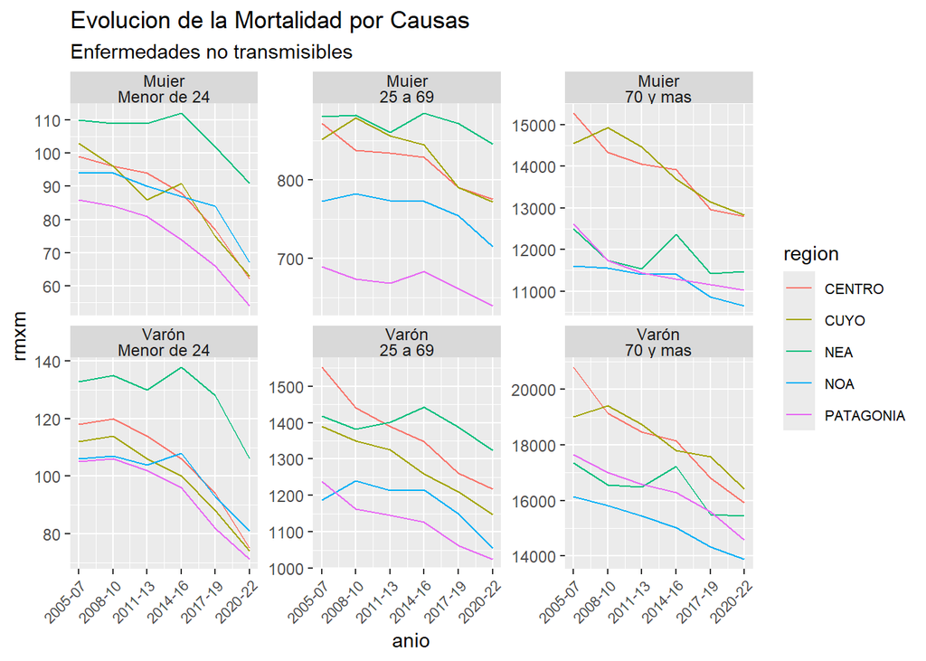

```r
grafico8
```

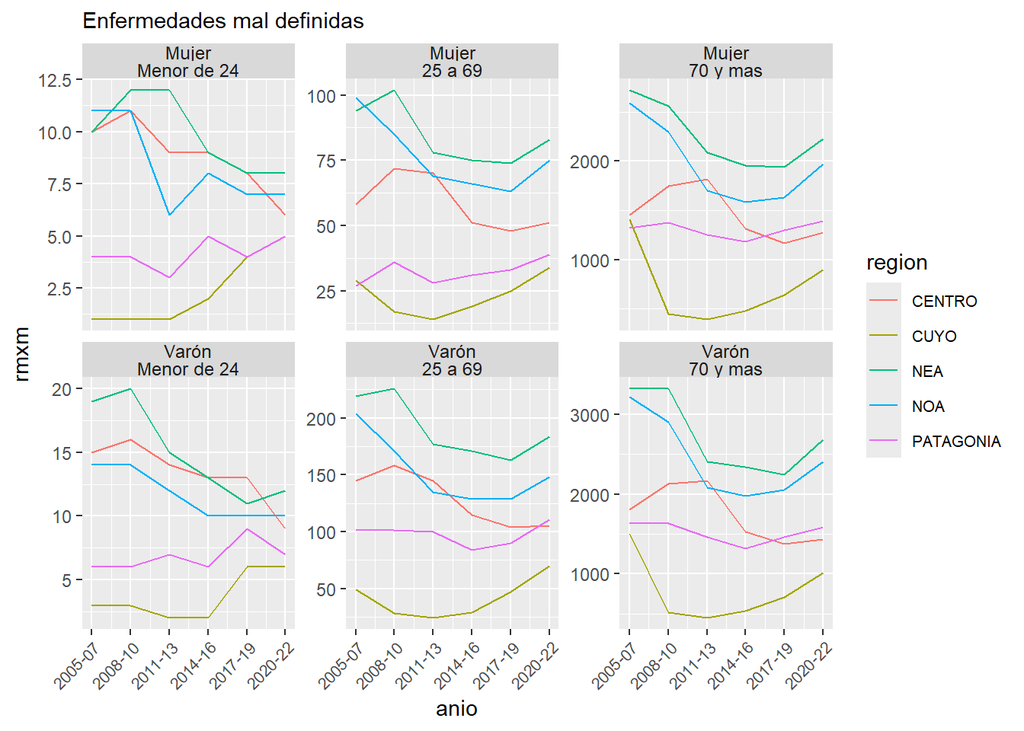

```r
grafico9
```

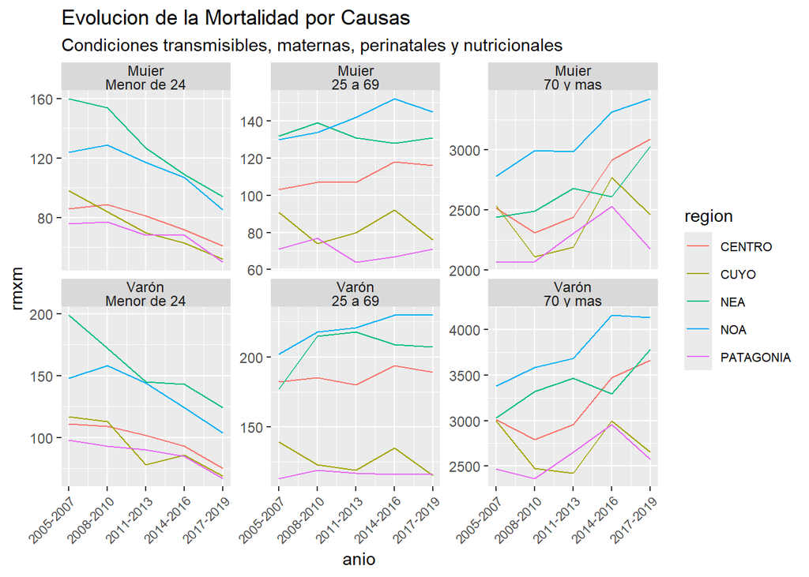

```r
grafico10
```

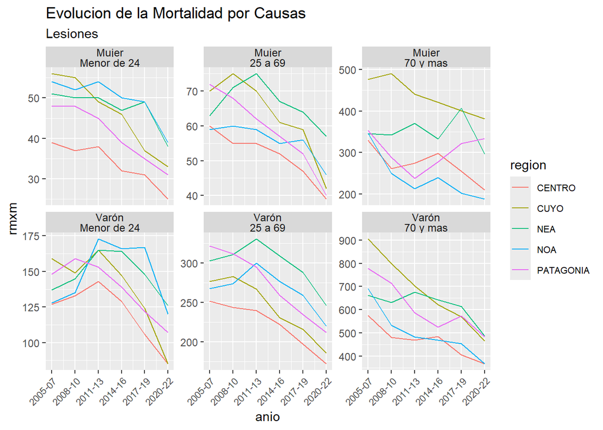

```r
grafico11
```

```r
# ggsave(plot = grafico8  , filename = "salida_graf/mort_reg_grupo1.png")
# ggsave(plot = grafico9  , filename = "salida_graf/mort_reg_grupo2.png")
# ggsave(plot = grafico10 , filename = "salida_graf/mort_reg_grupo3.png")
# ggsave(plot = grafico11 , filename = "salida_graf/mort_reg_grupo4.png")
```

```r
# patchwork::wrap_plots(grafico8, grafico9)
```

```r
# patchwork::wrap_plots(ncol = 1, grafico5, grafico6, grafico7)
```

```r
glimpse(data_mort_reg)
```

```
## Rows: 840
## Columns: 10
## $ anio      <dbl> 2003, 2003, 2003, 2003, 2003, 2003, 2003, 2003, 2003, 2003, …
## $ Años      <chr> "2001-2004", "2001-2004", "2001-2004", "2001-2004", "2001-20…
## $ gedad     <chr> "Menor de 24", "Menor de 24", "Menor de 24", "Menor de 24", …
## $ sexo      <chr> "Mujer", "Mujer", "Mujer", "Mujer", "Mujer", "Mujer", "Mujer…
## $ region    <chr> "CENTRO", "CENTRO", "CENTRO", "CENTRO", "CUYO", "CUYO", "CUY…
## $ grupo_oms <chr> "Condiciones transmisibles, maternas, perinatales y nutricio…
## $ casos     <int> 7094, 636, 7162, 2853, 887, 25, 851, 477, 2764, 223, 1531, 6…
## $ pob       <dbl> 5147618, 5147618, 5147618, 5147618, 609067, 609067, 609067, …
## $ rm        <dbl> 0.0013781, 0.0001236, 0.0013913, 0.0005542, 0.0014563, 0.000…
## $ rmxm      <dbl> 138, 12, 139, 55, 146, 4, 140, 78, 301, 24, 167, 69, 228, 21…
```

```r
# write.csv2(data_mort_reg, "~/GitHub/dinamica_mortalidad/excel_tablas/mortalidad_regiones.csv", fileEncoding = "latin1")
```

## 1.2 Razon de las Razones

Una forma de analisis comparativo es calcular una razon entre “las tasas”, en este caso la razon de mortalidad del trienio. Se realiza en relacion a la region centro. pero podria ser en relacion al total nacional.

```r
subset_centro <- data_mort_reg |>
  filter(Años == "2017-2019", region == "CENTRO") |>
  select(gedad, sexo, grupo_oms, rmxm) |>
  rename(rmxm_centro = rmxm)
```

```r
data_mort_reg |>
  filter(Años == "2017-2019") |>
  select(region, gedad, sexo, grupo_oms, rmxm) |>
  left_join(subset_centro, by=c("gedad", "sexo", "grupo_oms")) |>
  mutate(
    razon_2018 = rmxm / rmxm_centro - 1
  ) |>
  filter(region != "CENTRO") |>
  mutate(
    cond = if_else(razon_2018 > 0,
    "Mayor",
    "Menor")
  ) |>
  DT::datatable()
```

|  | region | gedad | sexo | grupo_oms | rmxm | rmxm_centro | razon_2018 | cond |
| --- | --- | --- | --- | --- | --- | --- | --- | --- |
| 1 | CUYO | Menor de 24 | Mujer | Condiciones transmisibles, maternas, perinatales y nutricionales | 52 | 61 | -0.1475409836065574 | Menor |
| 2 | CUYO | Menor de 24 | Mujer | Enfermedades mal definidas | 4 | 8 | -0.5 | Menor |
| 3 | CUYO | Menor de 24 | Mujer | Enfermedades no transmisibles | 75 | 77 | -0.02597402597402598 | Menor |
| 4 | CUYO | Menor de 24 | Mujer | Lesiones | 37 | 31 | 0.1935483870967742 | Mayor |
| 5 | NEA | Menor de 24 | Mujer | Condiciones transmisibles, maternas, perinatales y nutricionales | 94 | 61 | 0.540983606557377 | Mayor |
| 6 | NEA | Menor de 24 | Mujer | Enfermedades mal definidas | 8 | 8 | 0 | Menor |
| 7 | NEA | Menor de 24 | Mujer | Enfermedades no transmisibles | 102 | 77 | 0.3246753246753247 | Mayor |
| 8 | NEA | Menor de 24 | Mujer | Lesiones | 49 | 31 | 0.5806451612903225 | Mayor |
| 9 | NOA | Menor de 24 | Mujer | Condiciones transmisibles, maternas, perinatales y nutricionales | 85 | 61 | 0.3934426229508197 | Mayor |
| 10 | NOA | Menor de 24 | Mujer | Enfermedades mal definidas | 7 | 8 | -0.125 | Menor |

[output cut: 86 more lines]

## 1.3 Provincias

El analisis provincial implica desafios debido al numero de unidades de area, y las variaciones. Se analizan en el siguiente capitulo

```r
kableExtra::kbl(regiones) |>
  kableExtra::kable_classic()
```

| code_prov | region |
| --- | --- |
| 90 | NOA |
| 10 | NOA |
| 46 | NOA |
| 86 | NOA |
| 38 | NOA |
| 66 | NOA |
| 34 | NEA |
| 22 | NEA |
| 18 | NEA |
| 54 | NEA |
| 82 | CENTRO |
| 30 | CENTRO |
| 6 | CENTRO |
| 42 | CENTRO |
| 14 | CENTRO |
| 2 | CENTRO |
| 74 | CUYO |
| 70 | CUYO |
| 50 | CUYO |
| 26 | PATAGONIA |
| 78 | PATAGONIA |
| 62 | PATAGONIA |
| 58 | PATAGONIA |
| 94 | PATAGONIA |